# Correlation

```r
library(tidyverse)
```

```r
mtcars %>%
    select(wt, mpg) %>%
    glimpse()
```

```
Rows: 32
Columns: 2
$ wt  <dbl> 2.620, 2.875, 2.320, 3.215, 3.440, 3.460, 3.570, 3.190, 3.150, 3.440, 3.440, 4.070, 3.730, 3.78…
$ mpg <dbl> 21.0, 21.0, 22.8, 21.4, 18.7, 18.1, 14.3, 24.4, 22.8, 19.2, 17.8, 16.4, 17.3, 15.2, 10.4, 10.4,…
```

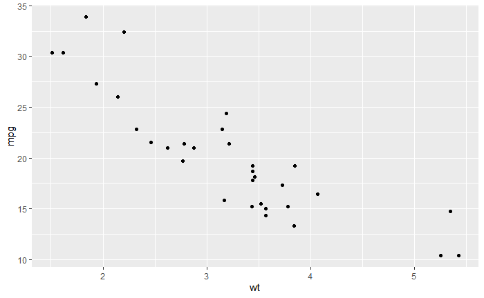

## Pearson correlation coefficient - denoted by `r`

- r has no units (it’s just a number)
- it takes bounded values (betweem -1 and 1)
  - approaching r = 1 when variables are strongly positively correlated
  - approaching r = -1 when strongly negatively correlated
  - near r = 0 when not correlated

We can calculate r using the `cor()` function (Pearson r is the default)

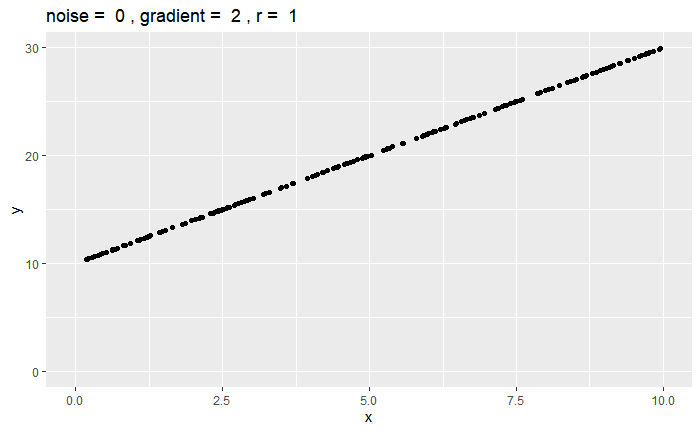

The magnitude of r:

0 - no correlation 0.01 - 0.19 - very weak 0.2 - 0.39 - weak 0.4 - 0.59 moderate 0.6 - 0.79 - strong 0.8 - 0.99 - very strong 1 - perfect

Let’s calculate the correlation coefficient for `wt` and `mpg` in mtcars

| cor(wt, mpg) |
| --- |
| -0.8676594 |

Order of variables doesn’t matter

##word of warning

The correlation coefficient is a blunt instrument - we can run `cor()` on any bivariate dataset and get a number out - regardless of any real trend in the data (if any)

## The most famous phrase in statistics!

**Correlation is not causation**

Just because two variables are **correlated** does not mean that one of them **causes** the change in the other

Consider `sunglasses_sold` and the amount of `ice_cream_sold` at a beach store in one week

- there’s a good chance these will be correlated
- but does this mean that the amount of sunglasses sold **causes** the amount of ice cream sold to increase?? No! We don’t have a strong enough basis to make this conclusion

## The ‘third variable’ problem

The simplest realistic model might be that **both** these variables are themselves casually related with a third **hidden variable**

What possible third variable could cause an increase in ice cream sold and sunglasses sold?

AKA **confounding variable**

## The ‘directionality’ problem

Even if two variables **are** causally related, there is nothing in the statistics to indicate **directionality** of causation

e.g. we measure `amount_of_exercise` in a given week and `happiness` in a given week

and we discover positive correlation between these

we might be tempted to say that more exercise leads to happier people - but maybe happier people exercise more!

## How do we prove causation?

Ideally, with a randomised controlled experiment

These give us the basis to say whether or not our ‘intervention’ variable **causes** any change we find in the ‘outcome’ variables.